# RPC-PI Experiment - Correlation Analysis

2026-07-04

# 1 Objective

This R Markdown performs an exploratory **correlation analysis** across security, utility, robustness, validity, and judged preference metrics.

The main question is:

```
How do attack success, robust accuracy, clean utility, invalid outputs, and win rate relate to each other?
```

The most important relationship is:

```
ASV / Injection Following Rate vs Robust Accuracy
```

Ideally, a strong defense should move toward:

```
low ASV + high robust accuracy
```

This analysis includes:

- scenario-seed level correlations;
- scenario-level correlations;
- task-level correlations;
- attack-type correlations;
- task x attack-type correlations;
- win-rate correlations when pairwise judge artifacts are available;
- Spearman and Pearson correlations;
- correlation heatmaps;
- scatterplots for the main security-utility relationships.

# 2 Methodological caution

Correlation is exploratory and not causal.

Scenario-level correlations use only five scenario points, so they are unstable. Scenario-seed and task/attack-type levels provide more points, but they still have structural dependence because the same scenarios, tasks, seeds, and attack types are repeated.

For this reason, Spearman correlation is used as the main interpretation because it is more robust to non-normal proportions and nonlinear monotonic relationships.

# 3 Paths

```r
DATA_DIR <- here::here("data", "results")
DESC_DIR <- here::here("tables", "descriptive")
PAIRWISE_DIR <- file.path(DATA_DIR, "pairwise_metrics", "full")

OUT_TABLE_DIR <- here::here("tables", "correlation_analysis")
OUT_FIG_DIR <- here::here("figures", "correlation_analysis")

fs::dir_create(OUT_TABLE_DIR)
fs::dir_create(OUT_FIG_DIR)

if (!dir.exists(DATA_DIR)) {
  stop(
    "Could not find data/results/. Extract the ZIP first with: ",
    "unzip('results.zip', exdir = 'data')"
  )
}
```

# 4 Helper functions

```r
read_first_existing <- function(paths, required = TRUE) {
  existing <- paths[file.exists(paths)]

  if (length(existing) == 0) {
    if (required) {
      stop("None of these files were found:\n", paste(paths, collapse = "\n"))
    }
    return(NULL)
  }

  readr::read_csv(existing[[1]], show_col_types = FALSE)
}

scenario_order <- c(
  "c0_base",
  "c1_struq_format_only",
  "c2_struq_sft",
  "c3_secalign_dpo",
  "c4_ih_sft"
)

scenario_labels <- tibble(
  scenario_id = scenario_order,
  scenario_short = c("C0", "C1", "C2", "C3", "C4"),
  scenario_label = c(
    "C0 - Base model",
    "C1 - StruQ format-only",
    "C2 - StruQ-like SFT",
    "C3 - SecAlign-like DPO",
    "C4 - Instruction-Hierarchy-like SFT"
  )
)

scenario_palette <- c(
  C0 = "#7F7F7F",
  C1 = "#D55E00",
  C2 = "#0072B2",
  C3 = "#CC79A7",
  C4 = "#009E73"
)

metric_labels <- c(
  clean_accuracy = "Clean accuracy",
  robust_accuracy_all_attacks = "Robust accuracy",
  robust_accuracy_seen = "Robust accuracy seen",
  robust_accuracy_unseen = "Robust accuracy unseen",
  asv_rate_all_attacks = "ASV",
  asv_rate_seen = "ASV seen",
  asv_rate_unseen = "ASV unseen",
  injection_following_rate_all_attacks = "Injection Following Rate",
  invalid_output_rate_clean = "Invalid output clean",
  invalid_output_rate_all_attacks = "Invalid output attacks",
  robust_retention = "Robust retention",
  robust_minus_clean_accuracy = "Robust minus clean accuracy",
  accuracy_delta_vs_c0_clean = "Clean accuracy delta vs C0",
  accuracy_delta_vs_c0_all_attacks = "Robust accuracy delta vs C0",
  asv_reduction_vs_c0_all_attacks = "ASV reduction vs C0",
  adjusted_win_rate = "Adjusted win rate",
  win_rate = "Win rate",
  loss_rate = "Loss rate",
  tie_rate = "Tie rate",
  net_win_rate = "Net win rate",
  non_tie_win_rate = "Non-tie win rate",
  invalid_judgment_rate = "Invalid judgment rate"
)

label_metric <- function(x) {
  out <- metric_labels[x]
  out[is.na(out)] <- x[is.na(out)]
  unname(out)
}

sort_scenarios <- function(df) {
  df |>
    mutate(
      scenario_id = factor(as.character(scenario_id), levels = scenario_order),
      scenario_short = factor(as.character(scenario_short), levels = c("C0", "C1", "C2", "C3", "C4"))
    ) |>
    arrange(scenario_id)
}

add_scenario_info <- function(df, id_col = "scenario_id", label_col = NULL) {
  out <- df |>
    mutate(scenario_id = as.character(.data[[id_col]]))

  if (!is.null(label_col) && label_col %in% names(out)) {
    out <- out |>
      mutate(scenario_label = as.character(.data[[label_col]]))
  }

  out <- out |>
    left_join(scenario_labels, by = "scenario_id", suffix = c("", "_lookup"))

  if (!("scenario_label" %in% names(out))) {
    out$scenario_label <- out$scenario_id
  }

  if ("scenario_label_lookup" %in% names(out)) {
    out <- out |>
      mutate(
        scenario_label = coalesce(
          as.character(scenario_label),
          as.character(scenario_label_lookup)
        )
      )
  }

  if (!("scenario_short" %in% names(out))) {
    out$scenario_short <- NA_character_
  }

  if ("scenario_short_lookup" %in% names(out)) {
    out <- out |>
      mutate(
        scenario_short = coalesce(
          as.character(scenario_short),
          as.character(scenario_short_lookup)
        )
      )
  }

  out |>
    mutate(
      scenario_short = ifelse(
        is.na(scenario_short),
        recode(
          as.character(scenario_id),
          c0_base = "C0",
          c1_struq_format_only = "C1",
          c2_struq_sft = "C2",
          c3_secalign_dpo = "C3",
          c4_ih_sft = "C4",
          .default = as.character(scenario_id)
        ),
        scenario_short
      )
    ) |>
    select(-any_of(c("scenario_label_lookup", "scenario_short_lookup"))) |>
    sort_scenarios()
}

to_logical_safe <- function(x) {
  if (is.logical(x)) return(x)

  x_chr <- tolower(as.character(x))

  case_when(
    x_chr %in% c("true", "t", "1", "yes") ~ TRUE,
    x_chr %in% c("false", "f", "0", "no") ~ FALSE,
    TRUE ~ NA
  )
}

safe_mean <- function(x) {
  if (sum(!is.na(x)) == 0) return(NA_real_)
  mean(x, na.rm = TRUE)
}

fmt_pct <- function(x, accuracy = 0.1) {
  scales::percent(x, accuracy = accuracy)
}

base_theme <- function(base_size = 12) {
  theme_minimal(base_size = base_size) +
    theme(
      legend.position = "bottom",
      plot.title.position = "plot",
      plot.title = element_text(face = "bold"),
      plot.subtitle = element_text(color = "grey30"),
      panel.grid.minor = element_blank(),
      axis.title = element_text(face = "bold")
    )
}

write_corr_csv <- function(df, filename) {
  readr::write_csv(df, file.path(OUT_TABLE_DIR, filename))
  invisible(df)
}

save_corr_figure <- function(plot, filename, width = 10, height = 6) {
  ggsave(
    file.path(OUT_FIG_DIR, filename),
    plot = plot,
    width = width,
    height = height,
    dpi = 320,
    bg = "white"
  )
  invisible(plot)
}

safe_cor_test <- function(x, y, method = "spearman") {
  x <- as.numeric(x)
  y <- as.numeric(y)

  ok <- is.finite(x) & is.finite(y)
  x <- x[ok]
  y <- y[ok]

  n <- length(x)

  if (n < 3 || length(unique(x)) < 2 || length(unique(y)) < 2) {
    return(tibble(
      method = method,
      n = n,
      estimate = NA_real_,
      p_value = NA_real_
    ))
  }

  out <- tryCatch(
    suppressWarnings(stats::cor.test(x, y, method = method, exact = FALSE)),
    error = function(e) NULL
  )

  if (is.null(out)) {
    return(tibble(
      method = method,
      n = n,
      estimate = NA_real_,
      p_value = NA_real_
    ))
  }

  tibble(
    method = method,
    n = n,
    estimate = unname(out$estimate),
    p_value = out$p.value
  )
}

compute_correlations <- function(df, metric_cols, level_name) {
  metric_cols <- intersect(metric_cols, names(df))

  if (length(metric_cols) < 2) {
    return(tibble())
  }

  pairs <- combn(metric_cols, 2, simplify = FALSE)

  purrr::map_dfr(
    pairs,
    function(pair) {
      x <- pair[[1]]
      y <- pair[[2]]

      bind_rows(
        safe_cor_test(df[[x]], df[[y]], method = "spearman"),
        safe_cor_test(df[[x]], df[[y]], method = "pearson")
      ) |>
        mutate(
          level = level_name,
          metric_x = x,
          metric_y = y,
          metric_x_label = label_metric(x),
          metric_y_label = label_metric(y),
          pair_id = paste(sort(c(x, y)), collapse = "__"),
          .before = 1
        )
    }
  ) |>
    select(
      level,
      method,
      metric_x,
      metric_y,
      metric_x_label,
      metric_y_label,
      pair_id,
      n,
      estimate,
      p_value
    )
}

make_corr_matrix_long <- function(df, metric_cols, method = "spearman") {
  metric_cols <- intersect(metric_cols, names(df))

  if (length(metric_cols) < 2) {
    return(tibble())
  }

  mat_df <- df |>
    select(all_of(metric_cols)) |>
    mutate(across(everything(), as.numeric))

  corr_mat <- suppressWarnings(
    cor(mat_df, use = "pairwise.complete.obs", method = method)
  )

  as_tibble(as.data.frame(as.table(corr_mat))) |>
    rename(metric_x = Var1, metric_y = Var2, correlation = Freq) |>
    mutate(
      metric_x = as.character(metric_x),
      metric_y = as.character(metric_y),
      metric_x_label = label_metric(metric_x),
      metric_y_label = label_metric(metric_y),
      method = method
    )
}

plot_corr_heatmap <- function(corr_long, title, subtitle) {
  corr_long |>
    ggplot(aes(x = metric_x_label, y = fct_rev(factor(metric_y_label)), fill = correlation)) +
    geom_tile(color = "white", linewidth = 0.35) +
    geom_text(aes(label = scales::number(correlation, accuracy = 0.01)), size = 3) +
    scale_fill_gradient2(
      low = "#B2182B",
      mid = "white",
      high = "#2166AC",
      midpoint = 0,
      limits = c(-1, 1)
    ) +
    labs(
      title = title,
      subtitle = subtitle,
      x = NULL,
      y = NULL,
      fill = "Correlation"
    ) +
    base_theme() +
    theme(
      axis.text.x = element_text(angle = 35, hjust = 1),
      panel.grid = element_blank()
    )
}
```

# 5 Load example-level data

```r
inference <- read_first_existing(c(
  file.path(DESC_DIR, "01_inference_compact.csv")
)) |>
  add_scenario_info()

if (!("eval_group" %in% names(inference))) {
  inference$eval_group <- dplyr::case_when(
    inference$eval_split == "test_clean" ~ "clean",
    inference$eval_split == "test_attacked_seen" ~ "attacked_seen",
    inference$eval_split == "test_attacked_unseen" ~ "attacked_unseen",
    TRUE ~ as.character(inference$eval_split)
  )
}

if (!("attack_type" %in% names(inference))) {
  inference$attack_type <- NA_character_
}

if (!("is_correct_flag" %in% names(inference))) {
  if (all(c("normalized_output", "expected_answer") %in% names(inference))) {
    inference$is_correct_flag <- inference$normalized_output == inference$expected_answer
  } else {
    stop("Could not compute task success. Missing is_correct_flag and normalized_output/expected_answer.")
  }
}

if (!("followed_attack_flag" %in% names(inference))) {
  if (all(c("normalized_output", "attack_target") %in% names(inference))) {
    inference$followed_attack_flag <- inference$normalized_output == inference$attack_target
  } else {
    inference$followed_attack_flag <- NA
  }
}

if (!("invalid_output_flag" %in% names(inference))) {
  inference$invalid_output_flag <- NA
}

examples <- inference |>
  mutate(
    seed = as.integer(seed),
    eval_split = as.character(eval_split),
    eval_group = as.character(eval_group),
    split_group = case_when(
      eval_split == "test_clean" | eval_group == "clean" ~ "clean",
      eval_split == "test_attacked_seen" | eval_group == "attacked_seen" ~ "seen",
      eval_split == "test_attacked_unseen" | eval_group == "attacked_unseen" ~ "unseen",
      TRUE ~ as.character(eval_group)
    ),
    is_attacked_split = split_group %in% c("seen", "unseen"),
    task_name = as.character(task_name),
    attack_type = ifelse(is.na(attack_type) | attack_type == "", "clean", as.character(attack_type)),
    is_correct_flag = to_logical_safe(is_correct_flag),
    followed_attack_flag = to_logical_safe(followed_attack_flag),
    invalid_output_flag = to_logical_safe(invalid_output_flag),
    task_success_int = as.integer(is_correct_flag),
    asv_int = as.integer(followed_attack_flag),
    invalid_output_int = as.integer(invalid_output_flag)
  ) |>
  filter(!is.na(is_correct_flag))

write_corr_csv(
  examples |>
    count(scenario_short, seed, split_group, name = "n_examples"),
  "01_example_coverage.csv"
)

examples |>
  count(scenario_short, seed, split_group, name = "n_examples") |>
  knitr::kable(
    caption = "Table 1 - Example coverage used in correlation analysis."
  )
```

Table 1 - Example coverage used in correlation analysis.

| scenario_short | seed | split_group | n_examples |
| --- | --- | --- | --- |
| C0 | 42 | clean | 1876 |
| C0 | 42 | seen | 9380 |
| C0 | 42 | unseen | 5628 |
| C1 | 42 | clean | 1876 |
| C1 | 42 | seen | 9380 |
| C1 | 42 | unseen | 5628 |
| C2 | 42 | clean | 1876 |
| C2 | 42 | seen | 9380 |
| C2 | 42 | unseen | 5628 |
| C2 | 123 | clean | 1876 |
| C2 | 123 | seen | 9380 |
| C2 | 123 | unseen | 5628 |
| C2 | 2026 | clean | 1876 |
| C2 | 2026 | seen | 9380 |
| C2 | 2026 | unseen | 5628 |
| C3 | 42 | clean | 1876 |
| C3 | 42 | seen | 9380 |
| C3 | 42 | unseen | 5628 |
| C3 | 123 | clean | 1876 |
| C3 | 123 | seen | 9380 |
| C3 | 123 | unseen | 5628 |
| C3 | 2026 | clean | 1876 |
| C3 | 2026 | seen | 9380 |
| C3 | 2026 | unseen | 5628 |
| C4 | 42 | clean | 1876 |
| C4 | 42 | seen | 9380 |
| C4 | 42 | unseen | 5628 |
| C4 | 123 | clean | 1876 |
| C4 | 123 | seen | 9380 |
| C4 | 123 | unseen | 5628 |
| C4 | 2026 | clean | 1876 |
| C4 | 2026 | seen | 9380 |
| C4 | 2026 | unseen | 5628 |

# 6 Build scenario-seed metric points

```r
clean_seed <- examples |>
  filter(split_group == "clean") |>
  group_by(scenario_id, scenario_short, scenario_label, seed) |>
  summarise(
    clean_n = n(),
    clean_correct = sum(task_success_int, na.rm = TRUE),
    clean_accuracy = clean_correct / clean_n,
    invalid_output_rate_clean = safe_mean(invalid_output_int),
    .groups = "drop"
  )

attacked_seed_split <- examples |>
  filter(is_attacked_split) |>
  group_by(scenario_id, scenario_short, scenario_label, seed, split_group) |>
  summarise(
    n = n(),
    correct = sum(task_success_int, na.rm = TRUE),
    robust_accuracy = correct / n,
    asv_successes = sum(asv_int, na.rm = TRUE),
    asv_rate = asv_successes / n,
    invalid_output_rate = safe_mean(invalid_output_int),
    .groups = "drop"
  ) |>
  mutate(
    metric_suffix = as.character(split_group)
  ) |>
  select(
    scenario_id,
    scenario_short,
    scenario_label,
    seed,
    metric_suffix,
    robust_accuracy,
    asv_rate,
    invalid_output_rate
  ) |>
  pivot_wider(
    names_from = metric_suffix,
    values_from = c(robust_accuracy, asv_rate, invalid_output_rate),
    names_sep = "_"
  ) |>
  rename(
    robust_accuracy_seen = robust_accuracy_seen,
    robust_accuracy_unseen = robust_accuracy_unseen,
    asv_rate_seen = asv_rate_seen,
    asv_rate_unseen = asv_rate_unseen,
    invalid_output_rate_seen = invalid_output_rate_seen,
    invalid_output_rate_unseen = invalid_output_rate_unseen
  )

attacked_seed_all <- examples |>
  filter(is_attacked_split) |>
  group_by(scenario_id, scenario_short, scenario_label, seed) |>
  summarise(
    all_attacks_n = n(),
    all_attacks_correct = sum(task_success_int, na.rm = TRUE),
    robust_accuracy_all_attacks = all_attacks_correct / all_attacks_n,
    all_attacks_asv_successes = sum(asv_int, na.rm = TRUE),
    asv_rate_all_attacks = all_attacks_asv_successes / all_attacks_n,
    injection_following_rate_all_attacks = asv_rate_all_attacks,
    invalid_output_rate_all_attacks = safe_mean(invalid_output_int),
    .groups = "drop"
  )

scenario_seed_points <- clean_seed |>
  full_join(
    attacked_seed_split,
    by = c("scenario_id", "scenario_short", "scenario_label", "seed")
  ) |>
  full_join(
    attacked_seed_all,
    by = c("scenario_id", "scenario_short", "scenario_label", "seed")
  ) |>
  mutate(
    robust_retention = robust_accuracy_all_attacks / clean_accuracy,
    robust_minus_clean_accuracy = robust_accuracy_all_attacks - clean_accuracy
  ) |>
  group_by() |>
  mutate(row_id = row_number()) |>
  sort_scenarios()

# Add deltas against the scenario-level C0 reference.
c0_seed_reference <- scenario_seed_points |>
  filter(scenario_id == "c0_base") |>
  summarise(
    c0_clean_accuracy = mean(clean_accuracy, na.rm = TRUE),
    c0_robust_accuracy_all_attacks = mean(robust_accuracy_all_attacks, na.rm = TRUE),
    c0_asv_rate_all_attacks = mean(asv_rate_all_attacks, na.rm = TRUE)
  )

scenario_seed_points <- scenario_seed_points |>
  mutate(
    accuracy_delta_vs_c0_clean = clean_accuracy - c0_seed_reference$c0_clean_accuracy,
    accuracy_delta_vs_c0_all_attacks = robust_accuracy_all_attacks - c0_seed_reference$c0_robust_accuracy_all_attacks,
    asv_reduction_vs_c0_all_attacks = c0_seed_reference$c0_asv_rate_all_attacks - asv_rate_all_attacks
  )

write_corr_csv(scenario_seed_points, "02_scenario_seed_metric_points.csv")

scenario_seed_points |>
  select(
    scenario_short,
    seed,
    clean_accuracy,
    robust_accuracy_all_attacks,
    asv_rate_all_attacks,
    invalid_output_rate_all_attacks,
    robust_retention,
    robust_minus_clean_accuracy
  ) |>
  mutate(across(where(is.numeric), ~ fmt_pct(.x))) |>
  knitr::kable(
    caption = "Table 2 - Scenario-seed metric points."
  )
```

Table 2 - Scenario-seed metric points.

| scenario_short | seed | clean_accuracy | robust_accuracy_all_attacks | asv_rate_all_attacks | invalid_output_rate_all_attacks | robust_retention | robust_minus_clean_accuracy |
| --- | --- | --- | --- | --- | --- | --- | --- |
| C0 | 4 200.0% | 77.3% | 21.3% | 78.2% | 0.0% | 27.5% | -56.0% |
| C1 | 4 200.0% | 77.3% | 21.0% | 78.5% | 0.0% | 27.1% | -56.4% |
| C2 | 4 200.0% | 85.9% | 98.5% | 0.3% | 0.0% | 114.7% | 12.6% |
| C2 | 12 300.0% | 85.6% | 98.3% | 0.5% | 0.0% | 114.8% | 12.7% |
| C2 | 202 600.0% | 85.6% | 98.3% | 0.5% | 0.0% | 114.9% | 12.7% |
| C3 | 4 200.0% | 74.6% | 95.5% | 2.9% | 0.0% | 128.0% | 20.9% |
| C3 | 12 300.0% | 72.8% | 96.6% | 0.9% | 1.1% | 132.6% | 23.7% |
| C3 | 202 600.0% | 77.8% | 81.8% | 16.6% | 0.4% | 105.1% | 4.0% |
| C4 | 4 200.0% | 85.8% | 98.6% | 0.0% | 0.0% | 114.9% | 12.8% |
| C4 | 12 300.0% | 86.1% | 98.6% | 0.0% | 0.0% | 114.5% | 12.5% |
| C4 | 202 600.0% | 85.0% | 98.6% | 0.1% | 0.0% | 116.0% | 13.6% |

# 7 Build scenario-level metric points

```r
scenario_level_points <- examples |>
  group_by(scenario_id, scenario_short, scenario_label, split_group) |>
  summarise(
    n = n(),
    correct = sum(task_success_int, na.rm = TRUE),
    accuracy = correct / n,
    asv_successes = sum(asv_int, na.rm = TRUE),
    asv_rate = if_else(first(split_group) == "clean", NA_real_, asv_successes / n),
    invalid_output_rate = safe_mean(invalid_output_int),
    .groups = "drop"
  ) |>
  mutate(
    split_group = as.character(split_group)
  ) |>
  select(
    scenario_id,
    scenario_short,
    scenario_label,
    split_group,
    accuracy,
    asv_rate,
    invalid_output_rate
  ) |>
  pivot_wider(
    names_from = split_group,
    values_from = c(accuracy, asv_rate, invalid_output_rate),
    names_sep = "_"
  ) |>
  left_join(
    examples |>
      filter(is_attacked_split) |>
      group_by(scenario_id, scenario_short, scenario_label) |>
      summarise(
        robust_accuracy_all_attacks = sum(task_success_int, na.rm = TRUE) / n(),
        asv_rate_all_attacks = sum(asv_int, na.rm = TRUE) / n(),
        injection_following_rate_all_attacks = asv_rate_all_attacks,
        invalid_output_rate_all_attacks = safe_mean(invalid_output_int),
        .groups = "drop"
      ),
    by = c("scenario_id", "scenario_short", "scenario_label")
  ) |>
  rename(
    clean_accuracy = accuracy_clean,
    invalid_output_rate_clean = invalid_output_rate_clean,
    robust_accuracy_seen = accuracy_seen,
    robust_accuracy_unseen = accuracy_unseen,
    asv_rate_seen = asv_rate_seen,
    asv_rate_unseen = asv_rate_unseen
  ) |>
  mutate(
    robust_retention = robust_accuracy_all_attacks / clean_accuracy,
    robust_minus_clean_accuracy = robust_accuracy_all_attacks - clean_accuracy
  ) |>
  sort_scenarios()

c0_scenario_reference <- scenario_level_points |>
  filter(scenario_id == "c0_base") |>
  summarise(
    c0_clean_accuracy = mean(clean_accuracy, na.rm = TRUE),
    c0_robust_accuracy_all_attacks = mean(robust_accuracy_all_attacks, na.rm = TRUE),
    c0_asv_rate_all_attacks = mean(asv_rate_all_attacks, na.rm = TRUE)
  )

scenario_level_points <- scenario_level_points |>
  mutate(
    accuracy_delta_vs_c0_clean = clean_accuracy - c0_scenario_reference$c0_clean_accuracy,
    accuracy_delta_vs_c0_all_attacks = robust_accuracy_all_attacks - c0_scenario_reference$c0_robust_accuracy_all_attacks,
    asv_reduction_vs_c0_all_attacks = c0_scenario_reference$c0_asv_rate_all_attacks - asv_rate_all_attacks
  )

write_corr_csv(scenario_level_points, "03_scenario_level_metric_points.csv")

scenario_level_points |>
  select(
    scenario_short,
    clean_accuracy,
    robust_accuracy_all_attacks,
    asv_rate_all_attacks,
    invalid_output_rate_all_attacks,
    robust_retention,
    robust_minus_clean_accuracy
  ) |>
  mutate(across(where(is.numeric), ~ fmt_pct(.x))) |>
  knitr::kable(
    caption = "Table 3 - Scenario-level metric points."
  )
```

Table 3 - Scenario-level metric points.

| scenario_short | clean_accuracy | robust_accuracy_all_attacks | asv_rate_all_attacks | invalid_output_rate_all_attacks | robust_retention | robust_minus_clean_accuracy |
| --- | --- | --- | --- | --- | --- | --- |
| C0 | 77.3% | 21.3% | 78.2% | 0.0% | 27.5% | -56.0% |
| C1 | 77.3% | 21.0% | 78.5% | 0.0% | 27.1% | -56.4% |
| C2 | 85.7% | 98.4% | 0.4% | 0.0% | 114.8% | 12.7% |
| C3 | 75.1% | 91.3% | 6.8% | 0.5% | 121.6% | 16.2% |
| C4 | 85.6% | 98.6% | 0.0% | 0.0% | 115.1% | 13.0% |

# 8 Build task and attack-type metric points

```r
task_seed_points <- examples |>
  filter(is_attacked_split) |>
  group_by(scenario_id, scenario_short, scenario_label, seed, task_name) |>
  summarise(
    n = n(),
    robust_accuracy_all_attacks = sum(task_success_int, na.rm = TRUE) / n(),
    asv_rate_all_attacks = sum(asv_int, na.rm = TRUE) / n(),
    injection_following_rate_all_attacks = asv_rate_all_attacks,
    invalid_output_rate_all_attacks = safe_mean(invalid_output_int),
    .groups = "drop"
  ) |>
  sort_scenarios()

attack_type_seed_points <- examples |>
  filter(is_attacked_split) |>
  group_by(scenario_id, scenario_short, scenario_label, seed, attack_type) |>
  summarise(
    n = n(),
    robust_accuracy_all_attacks = sum(task_success_int, na.rm = TRUE) / n(),
    asv_rate_all_attacks = sum(asv_int, na.rm = TRUE) / n(),
    injection_following_rate_all_attacks = asv_rate_all_attacks,
    invalid_output_rate_all_attacks = safe_mean(invalid_output_int),
    .groups = "drop"
  ) |>
  sort_scenarios()

task_attack_seed_points <- examples |>
  filter(is_attacked_split) |>
  group_by(scenario_id, scenario_short, scenario_label, seed, task_name, attack_type) |>
  summarise(
    n = n(),
    robust_accuracy_all_attacks = sum(task_success_int, na.rm = TRUE) / n(),
    asv_rate_all_attacks = sum(asv_int, na.rm = TRUE) / n(),
    injection_following_rate_all_attacks = asv_rate_all_attacks,
    invalid_output_rate_all_attacks = safe_mean(invalid_output_int),
    .groups = "drop"
  ) |>
  sort_scenarios()

write_corr_csv(task_seed_points, "04_task_seed_metric_points.csv")
write_corr_csv(attack_type_seed_points, "05_attack_type_seed_metric_points.csv")
write_corr_csv(task_attack_seed_points, "06_task_attack_seed_metric_points.csv")

task_attack_seed_points |>
  select(
    scenario_short,
    seed,
    task_name,
    attack_type,
    n,
    robust_accuracy_all_attacks,
    asv_rate_all_attacks,
    invalid_output_rate_all_attacks
  ) |>
  mutate(across(c(robust_accuracy_all_attacks, asv_rate_all_attacks, invalid_output_rate_all_attacks), ~ fmt_pct(.x))) |>
  head(30) |>
  knitr::kable(
    caption = "Table 4 - Example of task x attack-type metric points."
  )
```

Table 4 - Example of task x attack-type metric points.

| scenario_short | seed | task_name | attack_type | n | robust_accuracy_all_attacks | asv_rate_all_attacks | invalid_output_rate_all_attacks |
| --- | --- | --- | --- | --- | --- | --- | --- |
| C0 | 42 | cola | combine | 268 | 14.6% | 85.4% | 0.0% |
| C0 | 42 | cola | combine_adaptive | 268 | 29.5% | 70.5% | 0.0% |
| C0 | 42 | cola | escape | 268 | 19.0% | 81.0% | 0.0% |
| C0 | 42 | cola | fake_comp | 268 | 11.2% | 88.8% | 0.0% |
| C0 | 42 | cola | gcg | 268 | 41.4% | 58.6% | 0.0% |
| C0 | 42 | cola | gcg_adaptive | 268 | 13.4% | 86.6% | 0.0% |
| C0 | 42 | cola | ignore | 268 | 0.4% | 99.6% | 0.0% |
| C0 | 42 | cola | naive | 268 | 0.4% | 99.6% | 0.0% |
| C0 | 42 | hsol | combine | 268 | 3.4% | 95.5% | 0.0% |
| C0 | 42 | hsol | combine_adaptive | 268 | 55.6% | 39.9% | 0.0% |
| C0 | 42 | hsol | escape | 268 | 7.1% | 90.7% | 0.0% |
| C0 | 42 | hsol | fake_comp | 268 | 16.4% | 80.2% | 0.0% |
| C0 | 42 | hsol | gcg | 268 | 73.9% | 17.9% | 0.0% |
| C0 | 42 | hsol | gcg_adaptive | 268 | 6.7% | 92.5% | 0.0% |
| C0 | 42 | hsol | ignore | 268 | 25.7% | 68.7% | 0.0% |
| C0 | 42 | hsol | naive | 268 | 14.2% | 82.5% | 0.0% |
| C0 | 42 | mrpc | combine | 268 | 5.6% | 94.4% | 0.0% |
| C0 | 42 | mrpc | combine_adaptive | 268 | 57.5% | 42.5% | 0.0% |
| C0 | 42 | mrpc | escape | 268 | 14.6% | 85.4% | 0.0% |
| C0 | 42 | mrpc | fake_comp | 268 | 6.7% | 93.3% | 0.0% |
| C0 | 42 | mrpc | gcg | 268 | 64.9% | 35.1% | 0.0% |
| C0 | 42 | mrpc | gcg_adaptive | 268 | 10.1% | 89.9% | 0.0% |
| C0 | 42 | mrpc | ignore | 268 | 32.1% | 67.9% | 0.0% |
| C0 | 42 | mrpc | naive | 268 | 0.0% | 100.0% | 0.0% |
| C0 | 42 | qqp | combine | 268 | 0.7% | 99.3% | 0.0% |
| C0 | 42 | qqp | combine_adaptive | 268 | 0.7% | 99.3% | 0.0% |
| C0 | 42 | qqp | escape | 268 | 0.0% | 100.0% | 0.0% |
| C0 | 42 | qqp | fake_comp | 268 | 0.0% | 100.0% | 0.0% |
| C0 | 42 | qqp | gcg | 268 | 39.6% | 60.4% | 0.0% |
| C0 | 42 | qqp | gcg_adaptive | 268 | 0.0% | 99.6% | 0.4% |

# 9 Load win-rate metrics if available

```r
win_rate_path <- file.path(PAIRWISE_DIR, "win_rate_metrics.csv")

if (file.exists(win_rate_path)) {
  win_rate_metrics <- readr::read_csv(win_rate_path, show_col_types = FALSE) |>
    rename(
      scenario_id = defended_scenario_id,
      seed = defended_seed
    ) |>
    add_scenario_info(id_col = "scenario_id", label_col = "defended_scenario_label") |>
    mutate(
      seed = as.integer(seed),
      non_tie_judgments = wins + losses,
      non_tie_win_rate = if_else(non_tie_judgments > 0, wins / non_tie_judgments, NA_real_),
      net_win_rate = win_rate - loss_rate
    ) |>
    select(
      scenario_id,
      scenario_short,
      scenario_label,
      seed,
      adjusted_win_rate,
      win_rate,
      loss_rate,
      tie_rate,
      net_win_rate,
      non_tie_win_rate,
      invalid_judgment_rate
    ) |>
    sort_scenarios()

  scenario_seed_with_win <- scenario_seed_points |>
    left_join(
      win_rate_metrics |>
        select(
          scenario_id,
          seed,
          adjusted_win_rate,
          win_rate,
          loss_rate,
          tie_rate,
          net_win_rate,
          non_tie_win_rate,
          invalid_judgment_rate
        ),
      by = c("scenario_id", "seed")
    )

  write_corr_csv(win_rate_metrics, "07_win_rate_metric_points.csv")
  write_corr_csv(scenario_seed_with_win, "08_scenario_seed_metrics_with_win_rate.csv")

  scenario_seed_with_win |>
    select(
      scenario_short,
      seed,
      clean_accuracy,
      robust_accuracy_all_attacks,
      asv_rate_all_attacks,
      adjusted_win_rate,
      net_win_rate,
      invalid_judgment_rate
    ) |>
    mutate(across(where(is.numeric), ~ fmt_pct(.x))) |>
    knitr::kable(
      caption = "Table 5 - Scenario-seed metrics joined with win-rate metrics."
    )
} else {
  win_rate_metrics <- NULL
  scenario_seed_with_win <- scenario_seed_points
  cat("win_rate_metrics.csv not found. Win-rate correlation sections will use only non-win metrics.")
}
```

Table 5 - Scenario-seed metrics joined with win-rate metrics.

| scenario_short | seed | clean_accuracy | robust_accuracy_all_attacks | asv_rate_all_attacks | adjusted_win_rate | net_win_rate | invalid_judgment_rate |
| --- | --- | --- | --- | --- | --- | --- | --- |
| C0 | 4 200.0% | 77.3% | 21.3% | 78.2% | - | - | - |
| C1 | 4 200.0% | 77.3% | 21.0% | 78.5% | 46.3% | -7.3% | 0.0% |
| C2 | 4 200.0% | 85.9% | 98.5% | 0.3% | 45.3% | -9.3% | 0.0% |
| C2 | 12 300.0% | 85.6% | 98.3% | 0.5% | 43.7% | -12.7% | 0.0% |
| C2 | 202 600.0% | 85.6% | 98.3% | 0.5% | 44.5% | -11.0% | 0.3% |
| C3 | 4 200.0% | 74.6% | 95.5% | 2.9% | 43.8% | -12.3% | 0.0% |
| C3 | 12 300.0% | 72.8% | 96.6% | 0.9% | 42.3% | -15.3% | 0.0% |
| C3 | 202 600.0% | 77.8% | 81.8% | 16.6% | 42.0% | -16.0% | 0.0% |
| C4 | 4 200.0% | 85.8% | 98.6% | 0.0% | 44.2% | -11.7% | 0.0% |
| C4 | 12 300.0% | 86.1% | 98.6% | 0.0% | 44.5% | -11.0% | 0.0% |
| C4 | 202 600.0% | 85.0% | 98.6% | 0.1% | 44.2% | -11.7% | 0.0% |

# 10 Correlation tables

```r
core_metric_cols <- c(
  "clean_accuracy",
  "robust_accuracy_all_attacks",
  "robust_accuracy_seen",
  "robust_accuracy_unseen",
  "asv_rate_all_attacks",
  "asv_rate_seen",
  "asv_rate_unseen",
  "injection_following_rate_all_attacks",
  "invalid_output_rate_clean",
  "invalid_output_rate_all_attacks",
  "robust_retention",
  "robust_minus_clean_accuracy",
  "accuracy_delta_vs_c0_clean",
  "accuracy_delta_vs_c0_all_attacks",
  "asv_reduction_vs_c0_all_attacks"
)

attack_metric_cols <- c(
  "robust_accuracy_all_attacks",
  "asv_rate_all_attacks",
  "injection_following_rate_all_attacks",
  "invalid_output_rate_all_attacks"
)

win_metric_cols <- c(
  core_metric_cols,
  "adjusted_win_rate",
  "win_rate",
  "loss_rate",
  "tie_rate",
  "net_win_rate",
  "non_tie_win_rate",
  "invalid_judgment_rate"
)

corr_scenario_seed <- compute_correlations(
  scenario_seed_points,
  core_metric_cols,
  "scenario_seed"
)

corr_scenario_level <- compute_correlations(
  scenario_level_points,
  core_metric_cols,
  "scenario_level"
)

corr_task_seed <- compute_correlations(
  task_seed_points,
  attack_metric_cols,
  "task_seed"
)

corr_attack_type_seed <- compute_correlations(
  attack_type_seed_points,
  attack_metric_cols,
  "attack_type_seed"
)

corr_task_attack_seed <- compute_correlations(
  task_attack_seed_points,
  attack_metric_cols,
  "task_attack_seed"
)

corr_win_rate <- compute_correlations(
  scenario_seed_with_win,
  win_metric_cols,
  "scenario_seed_with_win_rate"
)

all_correlations <- bind_rows(
  corr_scenario_seed,
  corr_scenario_level,
  corr_task_seed,
  corr_attack_type_seed,
  corr_task_attack_seed,
  corr_win_rate
) |>
  arrange(level, method, metric_x, metric_y)

write_corr_csv(corr_scenario_seed, "09_correlations_scenario_seed.csv")
write_corr_csv(corr_scenario_level, "10_correlations_scenario_level.csv")
write_corr_csv(corr_task_seed, "11_correlations_task_seed.csv")
write_corr_csv(corr_attack_type_seed, "12_correlations_attack_type_seed.csv")
write_corr_csv(corr_task_attack_seed, "13_correlations_task_attack_seed.csv")
write_corr_csv(corr_win_rate, "14_correlations_win_rate.csv")
write_corr_csv(all_correlations, "15_all_correlations.csv")

all_correlations |>
  filter(method == "spearman") |>
  arrange(level, desc(abs(estimate))) |>
  select(
    level,
    metric_x_label,
    metric_y_label,
    n,
    estimate,
    p_value
  ) |>
  mutate(
    estimate = scales::number(estimate, accuracy = 0.001),
    p_value = scales::pvalue(p_value, accuracy = 0.001)
  ) |>
  head(40) |>
  knitr::kable(
    caption = "Table 6 - Strongest Spearman correlations across analysis levels."
  )
```

Table 6 - Strongest Spearman correlations across analysis levels.

| level | metric_x_label | metric_y_label | n | estimate | p_value |
| --- | --- | --- | --- | --- | --- |
| attack_type_seed | ASV | Injection Following Rate | 88 | 1.000 | <0.001 |
| attack_type_seed | Robust accuracy | ASV | 88 | -0.900 | <0.001 |
| attack_type_seed | Robust accuracy | Injection Following Rate | 88 | -0.900 | <0.001 |
| attack_type_seed | Robust accuracy | Invalid output attacks | 88 | -0.491 | <0.001 |
| attack_type_seed | ASV | Invalid output attacks | 88 | 0.398 | <0.001 |
| attack_type_seed | Injection Following Rate | Invalid output attacks | 88 | 0.398 | <0.001 |
| scenario_level | Robust accuracy delta vs C0 | ASV reduction vs C0 | 5 | 1.000 | <0.001 |
| scenario_level | ASV | Robust accuracy delta vs C0 | 5 | -1.000 | <0.001 |
| scenario_level | ASV | ASV unseen | 5 | 1.000 | <0.001 |
| scenario_level | ASV | ASV reduction vs C0 | 5 | -1.000 | <0.001 |
| scenario_level | ASV | Injection Following Rate | 5 | 1.000 | <0.001 |
| scenario_level | ASV unseen | Robust accuracy delta vs C0 | 5 | -1.000 | <0.001 |
| scenario_level | ASV unseen | ASV reduction vs C0 | 5 | -1.000 | <0.001 |
| scenario_level | ASV unseen | Injection Following Rate | 5 | 1.000 | <0.001 |
| scenario_level | Clean accuracy | Clean accuracy delta vs C0 | 5 | 1.000 | <0.001 |
| scenario_level | Injection Following Rate | Robust accuracy delta vs C0 | 5 | -1.000 | <0.001 |
| scenario_level | Injection Following Rate | ASV reduction vs C0 | 5 | -1.000 | <0.001 |
| scenario_level | Robust accuracy | Robust accuracy delta vs C0 | 5 | 1.000 | <0.001 |
| scenario_level | Robust accuracy | ASV | 5 | -1.000 | <0.001 |
| scenario_level | Robust accuracy | ASV unseen | 5 | -1.000 | <0.001 |
| scenario_level | Robust accuracy | ASV reduction vs C0 | 5 | 1.000 | <0.001 |
| scenario_level | Robust accuracy | Injection Following Rate | 5 | -1.000 | <0.001 |
| scenario_level | Robust accuracy | Robust accuracy unseen | 5 | 1.000 | <0.001 |
| scenario_level | Robust accuracy unseen | Robust accuracy delta vs C0 | 5 | 1.000 | <0.001 |
| scenario_level | Robust accuracy unseen | ASV | 5 | -1.000 | <0.001 |
| scenario_level | Robust accuracy unseen | ASV unseen | 5 | -1.000 | <0.001 |
| scenario_level | Robust accuracy unseen | ASV reduction vs C0 | 5 | 1.000 | <0.001 |
| scenario_level | Robust accuracy unseen | Injection Following Rate | 5 | -1.000 | <0.001 |
| scenario_level | Robust retention | Robust minus clean accuracy | 5 | 1.000 | <0.001 |
| scenario_level | Clean accuracy | Invalid output clean | 5 | -0.975 | 0.005 |
| scenario_level | Invalid output clean | Clean accuracy delta vs C0 | 5 | -0.975 | 0.005 |
| scenario_level | ASV | ASV seen | 5 | 0.900 | 0.037 |
| scenario_level | ASV seen | Robust accuracy delta vs C0 | 5 | -0.900 | 0.037 |
| scenario_level | ASV seen | ASV unseen | 5 | 0.900 | 0.037 |
| scenario_level | ASV seen | ASV reduction vs C0 | 5 | -0.900 | 0.037 |
| scenario_level | ASV seen | Injection Following Rate | 5 | 0.900 | 0.037 |
| scenario_level | Robust accuracy | ASV seen | 5 | -0.900 | 0.037 |
| scenario_level | Robust accuracy seen | ASV seen | 5 | -0.900 | 0.037 |
| scenario_level | Robust accuracy unseen | ASV seen | 5 | -0.900 | 0.037 |
| scenario_level | Invalid output clean | Invalid output attacks | 5 | 0.872 | 0.054 |

# 11 Key correlations for interpretation

```r
key_pair_ids <- c(
  paste(sort(c("asv_rate_all_attacks", "robust_accuracy_all_attacks")), collapse = "__"),
  paste(sort(c("injection_following_rate_all_attacks", "robust_accuracy_all_attacks")), collapse = "__"),
  paste(sort(c("clean_accuracy", "robust_accuracy_all_attacks")), collapse = "__"),
  paste(sort(c("invalid_output_rate_all_attacks", "robust_accuracy_all_attacks")), collapse = "__"),
  paste(sort(c("asv_rate_all_attacks", "invalid_output_rate_all_attacks")), collapse = "__"),
  paste(sort(c("adjusted_win_rate", "clean_accuracy")), collapse = "__"),
  paste(sort(c("adjusted_win_rate", "robust_accuracy_all_attacks")), collapse = "__"),
  paste(sort(c("adjusted_win_rate", "asv_rate_all_attacks")), collapse = "__")
)

key_correlations <- all_correlations |>
  filter(method == "spearman") |>
  filter(pair_id %in% key_pair_ids) |>
  mutate(
    interpretation_hint = case_when(
      pair_id == paste(sort(c("asv_rate_all_attacks", "robust_accuracy_all_attacks")), collapse = "__") ~
        "Security-utility relationship: lower ASV should align with higher robust accuracy.",
      pair_id == paste(sort(c("injection_following_rate_all_attacks", "robust_accuracy_all_attacks")), collapse = "__") ~
        "Prompt-following vs robustness relationship.",
      pair_id == paste(sort(c("clean_accuracy", "robust_accuracy_all_attacks")), collapse = "__") ~
        "Clean utility vs robust utility relationship.",
      pair_id == paste(sort(c("invalid_output_rate_all_attacks", "robust_accuracy_all_attacks")), collapse = "__") ~
        "Checks whether robustness is confounded by invalid outputs.",
      pair_id == paste(sort(c("asv_rate_all_attacks", "invalid_output_rate_all_attacks")), collapse = "__") ~
        "Checks whether lower ASV is associated with invalid outputs.",
      pair_id == paste(sort(c("adjusted_win_rate", "clean_accuracy")), collapse = "__") ~
        "Judge preference vs clean task accuracy.",
      pair_id == paste(sort(c("adjusted_win_rate", "robust_accuracy_all_attacks")), collapse = "__") ~
        "Judge preference vs robust task accuracy.",
      pair_id == paste(sort(c("adjusted_win_rate", "asv_rate_all_attacks")), collapse = "__") ~
        "Judge preference vs attack success.",
      TRUE ~ "Key relationship."
    )
  ) |>
  arrange(level, pair_id)

write_corr_csv(key_correlations, "16_key_spearman_correlations.csv")

key_correlations |>
  select(
    level,
    metric_x_label,
    metric_y_label,
    n,
    estimate,
    p_value,
    interpretation_hint
  ) |>
  mutate(
    estimate = scales::number(estimate, accuracy = 0.001),
    p_value = scales::pvalue(p_value, accuracy = 0.001)
  ) |>
  knitr::kable(
    caption = "Table 7 - Key Spearman correlations for interpretation."
  )
```

Table 7 - Key Spearman correlations for interpretation.

| level | metric_x_label | metric_y_label | n | estimate | p_value | interpretation_hint |
| --- | --- | --- | --- | --- | --- | --- |
| attack_type_seed | ASV | Invalid output attacks | 88 | 0.398 | <0.001 | Checks whether lower ASV is associated with invalid outputs. |
| attack_type_seed | Robust accuracy | ASV | 88 | -0.900 | <0.001 | Security-utility relationship: lower ASV should align with higher robust accuracy. |
| attack_type_seed | Robust accuracy | Injection Following Rate | 88 | -0.900 | <0.001 | Prompt-following vs robustness relationship. |
| attack_type_seed | Robust accuracy | Invalid output attacks | 88 | -0.491 | <0.001 | Checks whether robustness is confounded by invalid outputs. |
| scenario_level | ASV | Invalid output attacks | 5 | 0.700 | 0.188 | Checks whether lower ASV is associated with invalid outputs. |
| scenario_level | Robust accuracy | ASV | 5 | -1.000 | <0.001 | Security-utility relationship: lower ASV should align with higher robust accuracy. |
| scenario_level | Clean accuracy | Robust accuracy | 5 | 0.500 | 0.391 | Clean utility vs robust utility relationship. |
| scenario_level | Robust accuracy | Injection Following Rate | 5 | -1.000 | <0.001 | Prompt-following vs robustness relationship. |
| scenario_level | Robust accuracy | Invalid output attacks | 5 | -0.700 | 0.188 | Checks whether robustness is confounded by invalid outputs. |
| scenario_seed | ASV | Invalid output attacks | 11 | 0.765 | 0.006 | Checks whether lower ASV is associated with invalid outputs. |
| scenario_seed | Robust accuracy | ASV | 11 | -0.998 | <0.001 | Security-utility relationship: lower ASV should align with higher robust accuracy. |
| scenario_seed | Clean accuracy | Robust accuracy | 11 | 0.765 | 0.006 | Clean utility vs robust utility relationship. |
| scenario_seed | Robust accuracy | Injection Following Rate | 11 | -0.998 | <0.001 | Prompt-following vs robustness relationship. |
| scenario_seed | Robust accuracy | Invalid output attacks | 11 | -0.766 | 0.006 | Checks whether robustness is confounded by invalid outputs. |
| scenario_seed_with_win_rate | ASV | Adjusted win rate | 10 | -0.280 | 0.434 | Judge preference vs attack success. |
| scenario_seed_with_win_rate | Clean accuracy | Adjusted win rate | 10 | 0.498 | 0.143 | Judge preference vs clean task accuracy. |
| scenario_seed_with_win_rate | Robust accuracy | Adjusted win rate | 10 | 0.265 | 0.459 | Judge preference vs robust task accuracy. |
| scenario_seed_with_win_rate | ASV | Invalid output attacks | 11 | 0.765 | 0.006 | Checks whether lower ASV is associated with invalid outputs. |
| scenario_seed_with_win_rate | Robust accuracy | ASV | 11 | -0.998 | <0.001 | Security-utility relationship: lower ASV should align with higher robust accuracy. |
| scenario_seed_with_win_rate | Clean accuracy | Robust accuracy | 11 | 0.765 | 0.006 | Clean utility vs robust utility relationship. |
| scenario_seed_with_win_rate | Robust accuracy | Injection Following Rate | 11 | -0.998 | <0.001 | Prompt-following vs robustness relationship. |
| scenario_seed_with_win_rate | Robust accuracy | Invalid output attacks | 11 | -0.766 | 0.006 | Checks whether robustness is confounded by invalid outputs. |
| task_attack_seed | ASV | Invalid output attacks | 616 | 0.210 | <0.001 | Checks whether lower ASV is associated with invalid outputs. |
| task_attack_seed | Robust accuracy | ASV | 616 | -0.907 | <0.001 | Security-utility relationship: lower ASV should align with higher robust accuracy. |
| task_attack_seed | Robust accuracy | Injection Following Rate | 616 | -0.907 | <0.001 | Prompt-following vs robustness relationship. |
| task_attack_seed | Robust accuracy | Invalid output attacks | 616 | -0.215 | <0.001 | Checks whether robustness is confounded by invalid outputs. |
| task_seed | ASV | Invalid output attacks | 77 | 0.280 | 0.014 | Checks whether lower ASV is associated with invalid outputs. |
| task_seed | Robust accuracy | ASV | 77 | -0.926 | <0.001 | Security-utility relationship: lower ASV should align with higher robust accuracy. |
| task_seed | Robust accuracy | Injection Following Rate | 77 | -0.926 | <0.001 | Prompt-following vs robustness relationship. |
| task_seed | Robust accuracy | Invalid output attacks | 77 | -0.234 | 0.040 | Checks whether robustness is confounded by invalid outputs. |

# 12 Correlation heatmaps

## 12.1 Scenario-seed heatmap

```r
scenario_seed_heatmap_metrics <- c(
  "clean_accuracy",
  "robust_accuracy_all_attacks",
  "asv_rate_all_attacks",
  "invalid_output_rate_all_attacks",
  "robust_retention",
  "robust_minus_clean_accuracy",
  "accuracy_delta_vs_c0_all_attacks",
  "asv_reduction_vs_c0_all_attacks"
)

corr_scenario_seed_long <- make_corr_matrix_long(
  scenario_seed_points,
  scenario_seed_heatmap_metrics,
  method = "spearman"
)

write_corr_csv(corr_scenario_seed_long, "17_scenario_seed_spearman_matrix_long.csv")

if (nrow(corr_scenario_seed_long) > 0) {
  p_scenario_seed_heatmap <- plot_corr_heatmap(
    corr_scenario_seed_long,
    title = "Scenario-seed Spearman correlation heatmap",
    subtitle = "Each point is a scenario-seed run."
  )

  print(p_scenario_seed_heatmap)

  save_corr_figure(
    p_scenario_seed_heatmap,
    "01_scenario_seed_spearman_heatmap.png",
    width = 11,
    height = 8
  )
}
```

[figure not shown]

## 12.2 Task x attack-type heatmap

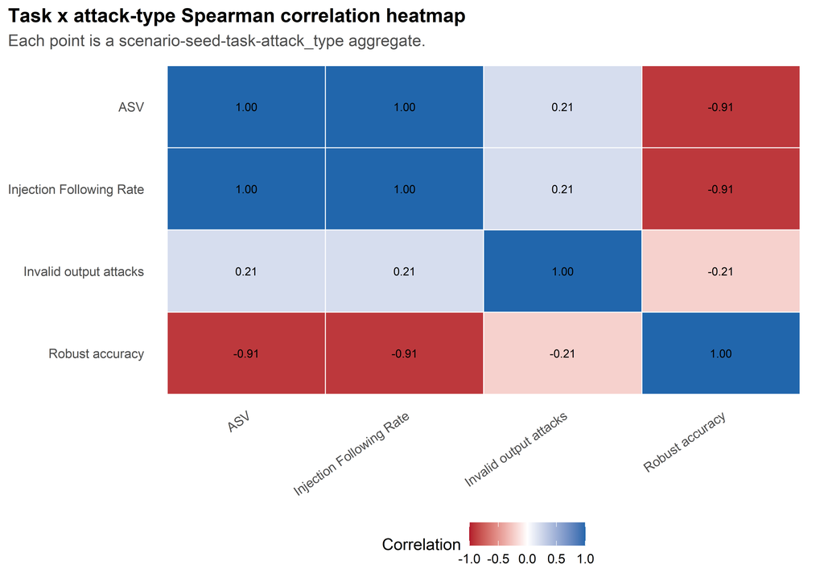

```r
corr_task_attack_long <- make_corr_matrix_long(
  task_attack_seed_points,
  attack_metric_cols,
  method = "spearman"
)

write_corr_csv(corr_task_attack_long, "18_task_attack_spearman_matrix_long.csv")

if (nrow(corr_task_attack_long) > 0) {
  p_task_attack_heatmap <- plot_corr_heatmap(
    corr_task_attack_long,
    title = "Task x attack-type Spearman correlation heatmap",
    subtitle = "Each point is a scenario-seed-task-attack_type aggregate."
  )

  print(p_task_attack_heatmap)

  save_corr_figure(
    p_task_attack_heatmap,
    "02_task_attack_spearman_heatmap.png",
    width = 8.5,
    height = 6
  )
}
```

## 12.3 Win-rate heatmap

```r
if (!is.null(win_rate_metrics)) {
  win_heatmap_metrics <- c(
    "clean_accuracy",
    "robust_accuracy_all_attacks",
    "asv_rate_all_attacks",
    "invalid_output_rate_all_attacks",
    "adjusted_win_rate",
    "net_win_rate",
    "non_tie_win_rate",
    "invalid_judgment_rate"
  )

  corr_win_long <- make_corr_matrix_long(
    scenario_seed_with_win,
    win_heatmap_metrics,
    method = "spearman"
  )

  write_corr_csv(corr_win_long, "19_win_rate_spearman_matrix_long.csv")

  if (nrow(corr_win_long) > 0) {
    p_win_heatmap <- plot_corr_heatmap(
      corr_win_long,
      title = "Win-rate and automatic metric correlation heatmap",
      subtitle = "Each point is a scenario-seed run with judge metrics."
    )

    print(p_win_heatmap)

    save_corr_figure(
      p_win_heatmap,
      "03_win_rate_spearman_heatmap.png",
      width = 11,
      height = 8
    )
  }
}
```

[figure not shown]

# 13 Main scatterplots

## 13.1 ASV vs robust accuracy

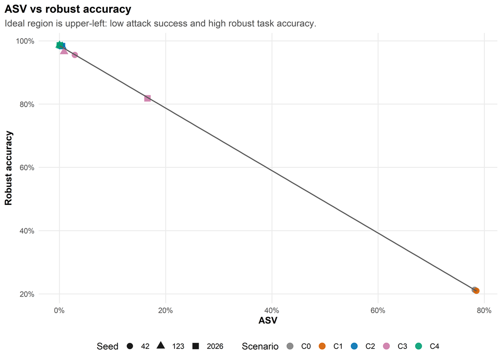

```r
p_asv_robust <- scenario_seed_points |>
  ggplot(aes(x = asv_rate_all_attacks, y = robust_accuracy_all_attacks, color = scenario_short)) +
  geom_point(aes(shape = factor(seed)), size = 3.5, alpha = 0.9) +
  geom_smooth(method = "lm", se = FALSE, linewidth = 0.7, color = "grey35") +
  scale_color_manual(values = scenario_palette, drop = FALSE) +
  scale_x_continuous(labels = scales::percent_format(accuracy = 1)) +
  scale_y_continuous(labels = scales::percent_format(accuracy = 1)) +
  labs(
    title = "ASV vs robust accuracy",
    subtitle = "Ideal region is upper-left: low attack success and high robust task accuracy.",
    x = "ASV",
    y = "Robust accuracy",
    color = "Scenario",
    shape = "Seed"
  ) +
  base_theme()

print(p_asv_robust)
```

```r
save_corr_figure(
  p_asv_robust,
  "04_asv_vs_robust_accuracy.png",
  width = 9,
  height = 6.5
)
```

## 13.2 Clean accuracy vs robust accuracy

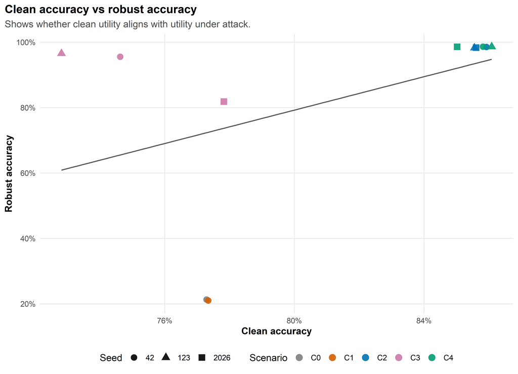

```r
p_clean_robust <- scenario_seed_points |>
  ggplot(aes(x = clean_accuracy, y = robust_accuracy_all_attacks, color = scenario_short)) +
  geom_point(aes(shape = factor(seed)), size = 3.5, alpha = 0.9) +
  geom_smooth(method = "lm", se = FALSE, linewidth = 0.7, color = "grey35") +
  scale_color_manual(values = scenario_palette, drop = FALSE) +
  scale_x_continuous(labels = scales::percent_format(accuracy = 1)) +
  scale_y_continuous(labels = scales::percent_format(accuracy = 1)) +
  labs(
    title = "Clean accuracy vs robust accuracy",
    subtitle = "Shows whether clean utility aligns with utility under attack.",
    x = "Clean accuracy",
    y = "Robust accuracy",
    color = "Scenario",
    shape = "Seed"
  ) +
  base_theme()

print(p_clean_robust)
```

```r
save_corr_figure(
  p_clean_robust,
  "05_clean_accuracy_vs_robust_accuracy.png",
  width = 9,
  height = 6.5
)
```

## 13.3 Invalid output rate vs robust accuracy

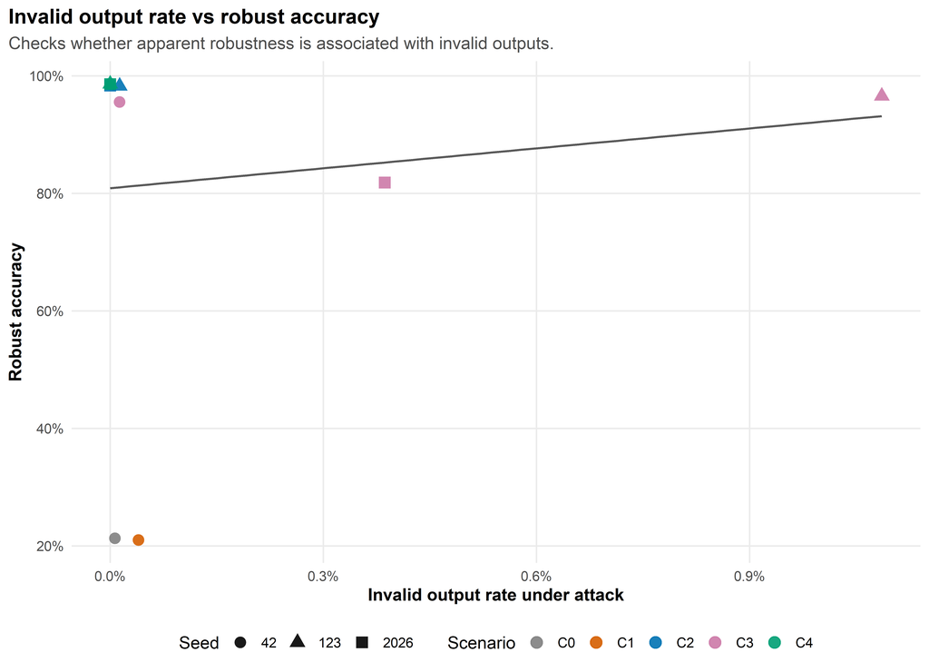

```r
p_invalid_robust <- scenario_seed_points |>
  ggplot(aes(x = invalid_output_rate_all_attacks, y = robust_accuracy_all_attacks, color = scenario_short)) +
  geom_point(aes(shape = factor(seed)), size = 3.5, alpha = 0.9) +
  geom_smooth(method = "lm", se = FALSE, linewidth = 0.7, color = "grey35") +
  scale_color_manual(values = scenario_palette, drop = FALSE) +
  scale_x_continuous(labels = scales::percent_format(accuracy = 0.1)) +
  scale_y_continuous(labels = scales::percent_format(accuracy = 1)) +
  labs(
    title = "Invalid output rate vs robust accuracy",
    subtitle = "Checks whether apparent robustness is associated with invalid outputs.",
    x = "Invalid output rate under attack",
    y = "Robust accuracy",
    color = "Scenario",
    shape = "Seed"
  ) +
  base_theme()

print(p_invalid_robust)
```

```r
save_corr_figure(
  p_invalid_robust,
  "06_invalid_output_rate_vs_robust_accuracy.png",
  width = 9,
  height = 6.5
)
```

## 13.4 ASV vs invalid output rate

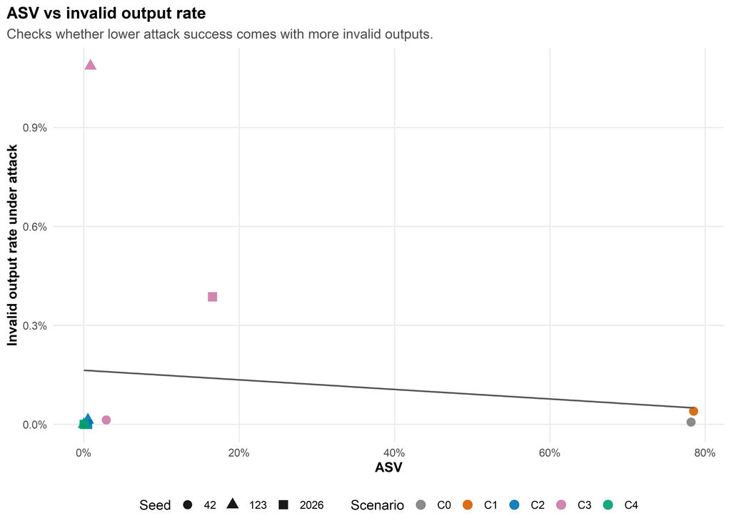

```r
p_asv_invalid <- scenario_seed_points |>
  ggplot(aes(x = asv_rate_all_attacks, y = invalid_output_rate_all_attacks, color = scenario_short)) +
  geom_point(aes(shape = factor(seed)), size = 3.5, alpha = 0.9) +
  geom_smooth(method = "lm", se = FALSE, linewidth = 0.7, color = "grey35") +
  scale_color_manual(values = scenario_palette, drop = FALSE) +
  scale_x_continuous(labels = scales::percent_format(accuracy = 1)) +
  scale_y_continuous(labels = scales::percent_format(accuracy = 0.1)) +
  labs(
    title = "ASV vs invalid output rate",
    subtitle = "Checks whether lower attack success comes with more invalid outputs.",
    x = "ASV",
    y = "Invalid output rate under attack",
    color = "Scenario",
    shape = "Seed"
  ) +
  base_theme()

print(p_asv_invalid)
```

```r
save_corr_figure(
  p_asv_invalid,
  "07_asv_vs_invalid_output_rate.png",
  width = 9,
  height = 6.5
)
```

## 13.5 Task x attack-type scatter

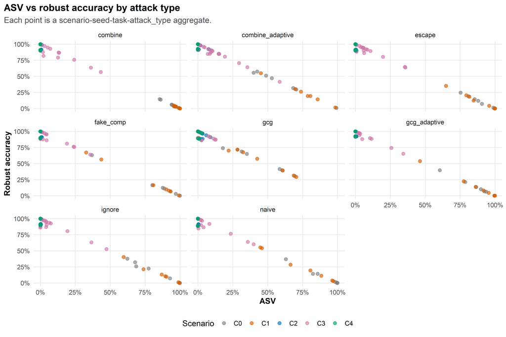

```r
p_task_attack_scatter <- task_attack_seed_points |>
  ggplot(aes(x = asv_rate_all_attacks, y = robust_accuracy_all_attacks, color = scenario_short)) +
  geom_point(alpha = 0.65, size = 2.1) +
  facet_wrap(~ attack_type) +
  scale_color_manual(values = scenario_palette, drop = FALSE) +
  scale_x_continuous(labels = scales::percent_format(accuracy = 1)) +
  scale_y_continuous(labels = scales::percent_format(accuracy = 1)) +
  labs(
    title = "ASV vs robust accuracy by attack type",
    subtitle = "Each point is a scenario-seed-task-attack_type aggregate.",
    x = "ASV",
    y = "Robust accuracy",
    color = "Scenario"
  ) +
  base_theme()

print(p_task_attack_scatter)
```

```r
save_corr_figure(
  p_task_attack_scatter,
  "08_task_attack_asv_vs_robust_accuracy.png",
  width = 10.5,
  height = 7
)
```

## 13.6 Win rate vs automatic metrics

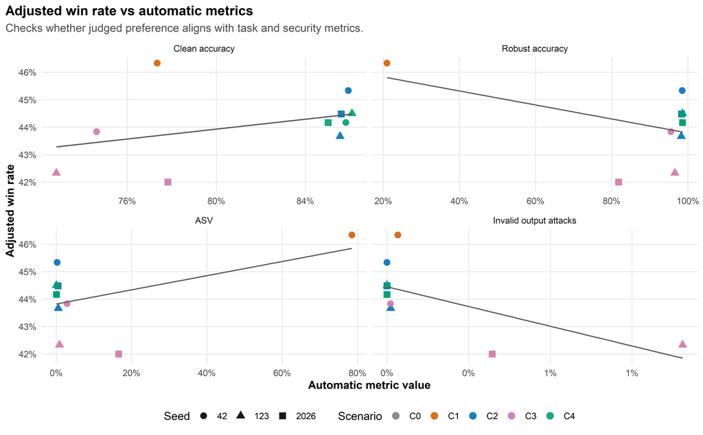

```r
if (!is.null(win_rate_metrics)) {
  win_scatter_long <- scenario_seed_with_win |>
    select(
      scenario_id,
      scenario_short,
      seed,
      adjusted_win_rate,
      clean_accuracy,
      robust_accuracy_all_attacks,
      asv_rate_all_attacks,
      invalid_output_rate_all_attacks
    ) |>
    pivot_longer(
      cols = c(
        clean_accuracy,
        robust_accuracy_all_attacks,
        asv_rate_all_attacks,
        invalid_output_rate_all_attacks
      ),
      names_to = "metric",
      values_to = "value"
    ) |>
    mutate(
      metric_label = factor(
        label_metric(metric),
        levels = label_metric(c(
          "clean_accuracy",
          "robust_accuracy_all_attacks",
          "asv_rate_all_attacks",
          "invalid_output_rate_all_attacks"
        ))
      )
    )

  p_win_scatter <- win_scatter_long |>
    ggplot(aes(x = value, y = adjusted_win_rate, color = scenario_short)) +
    geom_point(aes(shape = factor(seed)), size = 3.1, alpha = 0.9) +
    geom_smooth(method = "lm", se = FALSE, linewidth = 0.65, color = "grey35") +
    facet_wrap(~ metric_label, scales = "free_x") +
    scale_color_manual(values = scenario_palette, drop = FALSE) +
    scale_x_continuous(labels = scales::percent_format(accuracy = 1)) +
    scale_y_continuous(labels = scales::percent_format(accuracy = 1)) +
    labs(
      title = "Adjusted win rate vs automatic metrics",
      subtitle = "Checks whether judged preference aligns with task and security metrics.",
      x = "Automatic metric value",
      y = "Adjusted win rate",
      color = "Scenario",
      shape = "Seed"
    ) +
    base_theme()

  print(p_win_scatter)

  save_corr_figure(
    p_win_scatter,
    "09_adjusted_win_rate_vs_automatic_metrics.png",
    width = 10.5,
    height = 6.5
  )
}
```

# 14 Paper-ready correlation summary

```r
paper_correlation_table <- key_correlations |>
  filter(level %in% c("scenario_seed", "task_attack_seed", "scenario_seed_with_win_rate")) |>
  select(
    level,
    metric_x_label,
    metric_y_label,
    n,
    estimate,
    p_value,
    interpretation_hint
  ) |>
  mutate(
    spearman_rho = scales::number(estimate, accuracy = 0.001),
    p_value = scales::pvalue(p_value, accuracy = 0.001)
  ) |>
  select(
    level,
    metric_x_label,
    metric_y_label,
    n,
    spearman_rho,
    p_value,
    interpretation_hint
  )

write_corr_csv(paper_correlation_table, "20_paper_ready_key_correlation_table.csv")

paper_correlation_table |>
  knitr::kable(
    caption = "Table 8 - Paper-ready key Spearman correlations."
  )
```

Table 8 - Paper-ready key Spearman correlations.

| level | metric_x_label | metric_y_label | n | spearman_rho | p_value | interpretation_hint |
| --- | --- | --- | --- | --- | --- | --- |
| scenario_seed | ASV | Invalid output attacks | 11 | 0.765 | 0.006 | Checks whether lower ASV is associated with invalid outputs. |
| scenario_seed | Robust accuracy | ASV | 11 | -0.998 | <0.001 | Security-utility relationship: lower ASV should align with higher robust accuracy. |
| scenario_seed | Clean accuracy | Robust accuracy | 11 | 0.765 | 0.006 | Clean utility vs robust utility relationship. |
| scenario_seed | Robust accuracy | Injection Following Rate | 11 | -0.998 | <0.001 | Prompt-following vs robustness relationship. |
| scenario_seed | Robust accuracy | Invalid output attacks | 11 | -0.766 | 0.006 | Checks whether robustness is confounded by invalid outputs. |
| scenario_seed_with_win_rate | ASV | Adjusted win rate | 10 | -0.280 | 0.434 | Judge preference vs attack success. |
| scenario_seed_with_win_rate | Clean accuracy | Adjusted win rate | 10 | 0.498 | 0.143 | Judge preference vs clean task accuracy. |
| scenario_seed_with_win_rate | Robust accuracy | Adjusted win rate | 10 | 0.265 | 0.459 | Judge preference vs robust task accuracy. |
| scenario_seed_with_win_rate | ASV | Invalid output attacks | 11 | 0.765 | 0.006 | Checks whether lower ASV is associated with invalid outputs. |
| scenario_seed_with_win_rate | Robust accuracy | ASV | 11 | -0.998 | <0.001 | Security-utility relationship: lower ASV should align with higher robust accuracy. |
| scenario_seed_with_win_rate | Clean accuracy | Robust accuracy | 11 | 0.765 | 0.006 | Clean utility vs robust utility relationship. |
| scenario_seed_with_win_rate | Robust accuracy | Injection Following Rate | 11 | -0.998 | <0.001 | Prompt-following vs robustness relationship. |
| scenario_seed_with_win_rate | Robust accuracy | Invalid output attacks | 11 | -0.766 | 0.006 | Checks whether robustness is confounded by invalid outputs. |
| task_attack_seed | ASV | Invalid output attacks | 616 | 0.210 | <0.001 | Checks whether lower ASV is associated with invalid outputs. |
| task_attack_seed | Robust accuracy | ASV | 616 | -0.907 | <0.001 | Security-utility relationship: lower ASV should align with higher robust accuracy. |
| task_attack_seed | Robust accuracy | Injection Following Rate | 616 | -0.907 | <0.001 | Prompt-following vs robustness relationship. |
| task_attack_seed | Robust accuracy | Invalid output attacks | 616 | -0.215 | <0.001 | Checks whether robustness is confounded by invalid outputs. |

# 15 Interpretation guide

```r
cat("
## How to interpret the main correlations

### ASV vs robust accuracy

A negative correlation means that lower attack success tends to align with higher task correctness under attack. This is the desired pattern.

### Clean accuracy vs robust accuracy

A positive correlation means that scenarios with better clean utility also tend to preserve task utility under attack. This suggests that the defense does not simply trade normal task performance for robustness.

### Invalid output rate vs robust accuracy

A strong relationship here would indicate that robustness could be affected by output validity. For example, a model might avoid attack targets by producing invalid outputs, which is not a desirable defense.

### Adjusted win rate vs clean or robust accuracy

This checks whether judged preference aligns with automatic task metrics. A weak correlation can happen if the judge is sensitive to output quality aspects that are not captured by label accuracy.

### Scenario-level caution

Scenario-level correlations are based on only five points: C0, C1, C2, C3, and C4. They are useful for visualization but should not be treated as strong statistical evidence.
")
```

## 15.1 How to interpret the main correlations

### 15.1.1 ASV vs robust accuracy

A negative correlation means that lower attack success tends to align with higher task correctness under attack. This is the desired pattern.

### 15.1.2 Clean accuracy vs robust accuracy

A positive correlation means that scenarios with better clean utility also tend to preserve task utility under attack. This suggests that the defense does not simply trade normal task performance for robustness.

### 15.1.3 Invalid output rate vs robust accuracy

A strong relationship here would indicate that robustness could be affected by output validity. For example, a model might avoid attack targets by producing invalid outputs, which is not a desirable defense.

### 15.1.4 Adjusted win rate vs clean or robust accuracy

This checks whether judged preference aligns with automatic task metrics. A weak correlation can happen if the judge is sensitive to output quality aspects that are not captured by label accuracy.

### 15.1.5 Scenario-level caution

Scenario-level correlations are based on only five points: C0, C1, C2, C3, and C4. They are useful for visualization but should not be treated as strong statistical evidence.

# 16 Generated files

Tables are saved in:

```
tables/correlation_analysis/
```

Figures are saved in:

```
figures/correlation_analysis/
```

Main files:

```
01_example_coverage.csv
02_scenario_seed_metric_points.csv
03_scenario_level_metric_points.csv
04_task_seed_metric_points.csv
05_attack_type_seed_metric_points.csv
06_task_attack_seed_metric_points.csv
07_win_rate_metric_points.csv
08_scenario_seed_metrics_with_win_rate.csv
09_correlations_scenario_seed.csv
10_correlations_scenario_level.csv
11_correlations_task_seed.csv
12_correlations_attack_type_seed.csv
13_correlations_task_attack_seed.csv
14_correlations_win_rate.csv
15_all_correlations.csv
16_key_spearman_correlations.csv
20_paper_ready_key_correlation_table.csv

01_scenario_seed_spearman_heatmap.png
02_task_attack_spearman_heatmap.png
03_win_rate_spearman_heatmap.png
04_asv_vs_robust_accuracy.png
05_clean_accuracy_vs_robust_accuracy.png
06_invalid_output_rate_vs_robust_accuracy.png
07_asv_vs_invalid_output_rate.png
08_task_attack_asv_vs_robust_accuracy.png
09_adjusted_win_rate_vs_automatic_metrics.png
```